# Prediction of EW Volume BV’s using LGEP

Adam Festa

5/27/2018

## 0.1 Script objective

- Predict volume of EW using LGEP

## 0.2 Load data

```r
# Load counts
load("/mnt/mnt/media/disk6/ARF/RNASEQ/counts/86kSalmon/Step3_LMM_animal.RData")
head(rownames(asreml.counts))
```

```
## [1] "ped(animal_id, var = T)_GR011"  "ped(animal_id, var = T)_N05052"
## [3] "ped(animal_id, var = T)_N07002" "ped(animal_id, var = T)_N07022"
## [5] "ped(animal_id, var = T)_N07029" "ped(animal_id, var = T)_N07051"
```

```r
asreml.counts <- asreml.counts[-c(1:94),]
head(rownames(asreml.counts))
```

```
## [1] "ped(animal_id, var = T)_1030" "ped(animal_id, var = T)_1028"
## [3] "ped(animal_id, var = T)_1087" "ped(animal_id, var = T)_1013"
## [5] "ped(animal_id, var = T)_1012" "ped(animal_id, var = T)_1061"
```

```r
# Load phenos
load("/mnt/mnt/media/disk6/ARF/RNASEQ/Breeding-Value-Prediction/disk6directory/resources/expt.dat.720.RData")
# Change factor to character and subset 3 columns
expt.dat.720$fam_id <- as.character(expt.dat.720$fam_id)
select.columns <- c("fam_id","animal_id","Volume","Volume Accuracy","Height","index_seq","batch")

# Remove missing phenotypes and subset for phenos which have counts
fam.phenos <- unique(expt.dat.720[-which(is.na(expt.dat.720$Volume) == T),select.columns])

# Edit rownames of asreml.counts
 sub.names <- gsub(pattern = "animal_id, var = T)_",replacement = "",x = rownames(asreml.counts))
 sub.names <- gsub("ped\\(", "", sub.names)

# Subset each count data to contain only rows which have phenos
select.rows <- which(sub.names %in% as.character(fam.phenos$animal_id))

asreml.counts <- asreml.counts[select.rows,]

select.rows <- which(as.character(fam.phenos$animal_id) %in% sub.names)
fam.phenos <- fam.phenos[select.rows,]
```

```r
final.r.names <- gsub(pattern = "animal_id, var = T)_",replacement = "",x = rownames(asreml.counts))
final.r.names <- gsub("ped\\(", "", final.r.names)
head(as.character(fam.phenos$animal_id))
```

```
## [1] "1030" "1061" "1082" "1065" "1008" "1043"
```

```r
head(final.r.names)
```

```
## [1] "1030" "1061" "1082" "1065" "1008" "1043"
```

```r
rownames(asreml.counts) <- paste0(final.r.names,".",fam.phenos$index_seq)
rownames(fam.phenos) <- paste0(fam.phenos$animal_id,".",fam.phenos$index_seq)
```

## 0.3 Summary stats

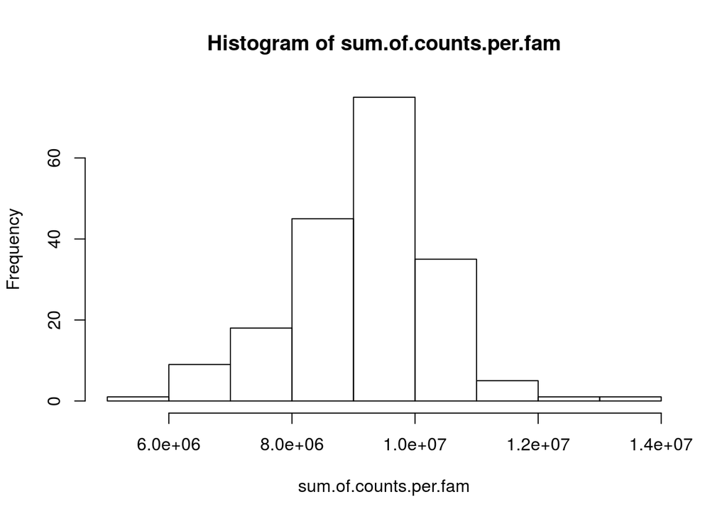

```r
sum.of.counts.per.gene <- apply(asreml.counts,2,sum)
sum.of.counts.per.fam <- apply(asreml.counts,1,sum)
hist(sum.of.counts.per.fam)
```

## 0.4 Generate family-level info

- Create family level phenotypes

```r
# First subset the unique fam, volume, batch combo to see what fams are in both batches
pheno.57 <- unique(fam.phenos[,c("fam_id","Volume","batch")])

# Identify which families were grown in both batches
crossover.fams <- names(which(table(pheno.57$fam_id) ==2))
crossover.fams
```

```
## [1] "N07056"  "N08001"  "N08103"  "N101027" "N111095"
```

```r
# Now get the unique list of family phenos
pheno.57 <- unique(fam.phenos[,c("fam_id","Volume","Volume Accuracy")])
```

- Create family mean counts

```r
fam.asreml.counts <- matrix(,nrow = 57,ncol=ncol(asreml.counts))
all.fams <- unique(as.character(fam.phenos$fam_id))
for(each.fam in 1:57){
 merge.bio.reps <-  which(fam.phenos$fam_id %in% all.fams[each.fam])
 if(length(merge.bio.reps) == 1){ fam.asreml.counts[each.fam,] <- asreml.counts[merge.bio.reps,]} else {
   fam.asreml.counts[each.fam,] <- apply(asreml.counts[merge.bio.reps,],2,mean)}
}
rownames(fam.asreml.counts) <- all.fams

rownames(pheno.57) <- pheno.57$fam_id
```

## 0.5 Predictions

- Establish the training and testing

```r
# Split test and train set by batch
ew.fams <- unique(fam.phenos$fam_id[which(fam.phenos$batch == "EW")])
lgep.fams <- unique(fam.phenos$fam_id[which(fam.phenos$batch == "LGEP")])

# Remove crossover fams from test set
ew.fams <- ew.fams[-which(ew.fams %in% crossover.fams)]
```

### 0.5.1 Omic Kriging

```r
suppressPackageStartupMessages(library(OmicKriging))
suppressPackageStartupMessages(library(Metrics))
```

#### 0.5.1.1 All transcripts: BIO Reps

- Bio-reps: NO SCALING

```r
cor.mat <- cor(t(scale(log2(asreml.counts + 1),center=F,scale = F)))
rownames(cor.mat) <- 1:190; colnames(cor.mat) <- 1:190
rownames(fam.phenos) <- 1:190

TRAIN.fams <- which(fam.phenos$fam_id %in% lgep.fams)
TEST.fams <- which(fam.phenos$fam_id %in% ew.fams)

predictions <- okriging(idtest = TEST.fams,idtrain = TRAIN.fams,corlist = list(cor.mat),H2vec = c(.99),pheno = fam.phenos,phenoname = "Volume")

cor(predictions$Ypred,predictions$Ytest)
```

```
## [1] 0.2361682
```

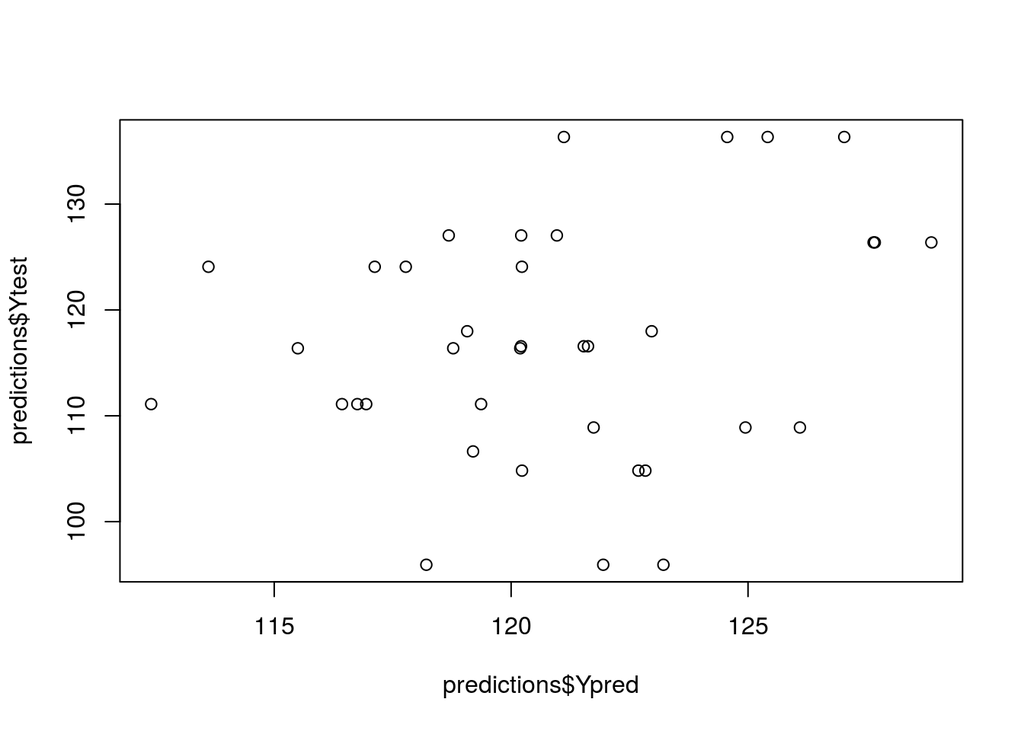

```r
plot(predictions$Ypred,predictions$Ytest)
```

- Bio-reps: SCALED, NO CENTERING

```r
cor.mat <- cor(t(scale(log2(asreml.counts + 1),center=F,scale = T)))
rownames(cor.mat) <- 1:190; colnames(cor.mat) <- 1:190
rownames(fam.phenos) <- 1:190

TRAIN.fams <- which(fam.phenos$fam_id %in% lgep.fams)
TEST.fams <- which(fam.phenos$fam_id %in% ew.fams)

predictions <- okriging(idtest = TEST.fams,idtrain = TRAIN.fams,corlist = list(cor.mat),H2vec = c(.99),pheno = fam.phenos,phenoname = "Volume")

cor(predictions$Ypred,predictions$Ytest)
```

```
## [1] 0.02624271
```

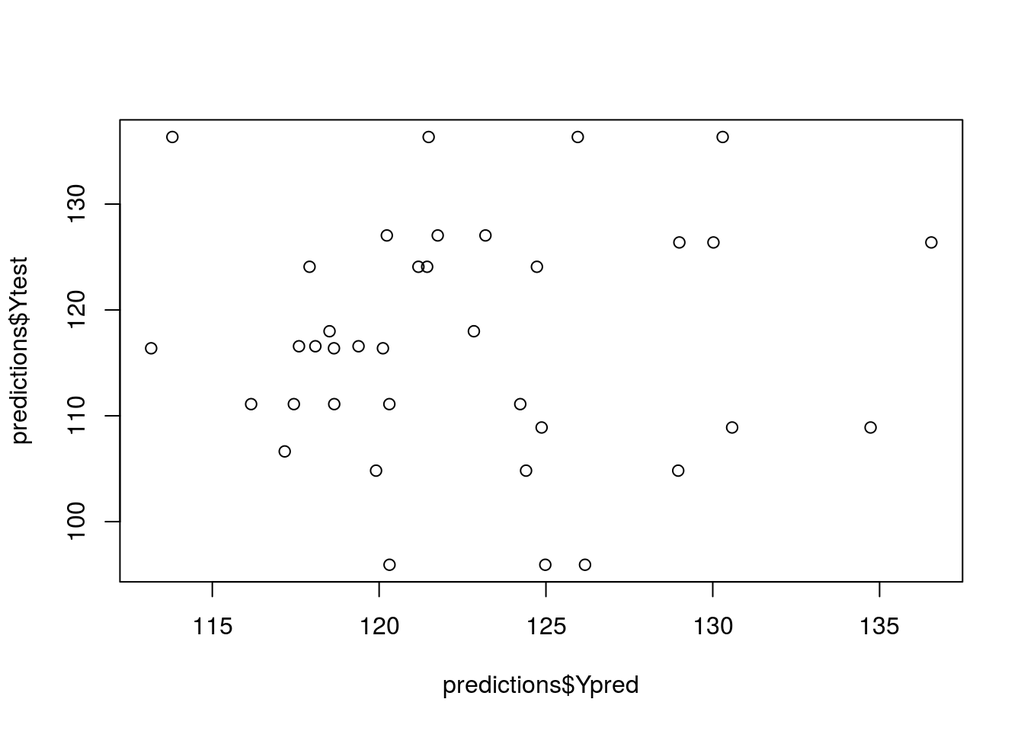

```r
plot(predictions$Ypred,predictions$Ytest)
```

- Bio-reps: SCALED & CENTERED

```r
cor.mat <- cor(t(scale(log2(asreml.counts + 1),center=T,scale = T)))
rownames(cor.mat) <- 1:190; colnames(cor.mat) <- 1:190
rownames(fam.phenos) <- 1:190

TRAIN.fams <- which(fam.phenos$fam_id %in% lgep.fams)
TEST.fams <- which(fam.phenos$fam_id %in% ew.fams)

predictions <- okriging(idtest = TEST.fams,idtrain = TRAIN.fams,corlist = list(cor.mat),H2vec = c(.99),pheno = fam.phenos,phenoname = "Volume")

cor(predictions$Ypred,predictions$Ytest)
```

```
## [1] -0.07774653
```

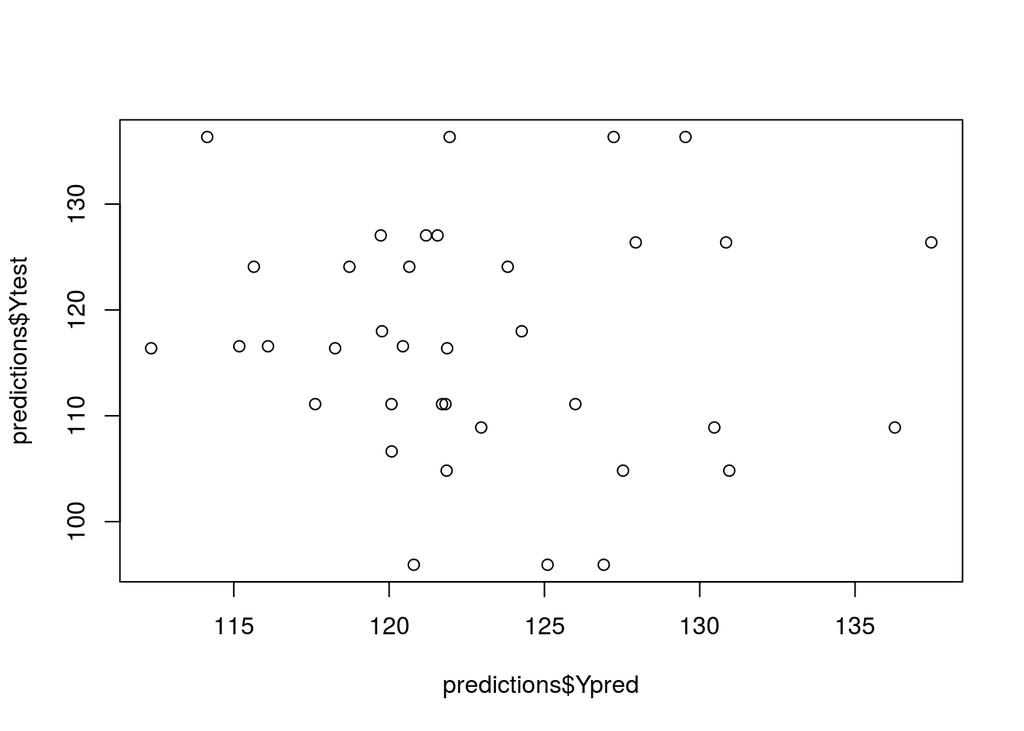

```r
plot(predictions$Ypred,predictions$Ytest)
```

*** The BEST result from Bio replicates is using log2 with NO SCALING/CENTERING

#### 0.5.1.2 All transcripts: FAMILY-level

- Fam reps: NO SCALING/CENTERING

```r
cor.mat <- cor(t(scale(log2(fam.asreml.counts + 1),center=F,scale = F)))
TRAIN.fams <- lgep.fams
TEST.fams <- ew.fams

predictions <- okriging(idtest = TEST.fams,idtrain = TRAIN.fams,corlist = list(cor.mat),H2vec = c(.99),pheno = pheno.57,phenoname = "Volume")

cor(predictions$Ypred,predictions$Ytest)
```

```
## [1] 0.173975
```

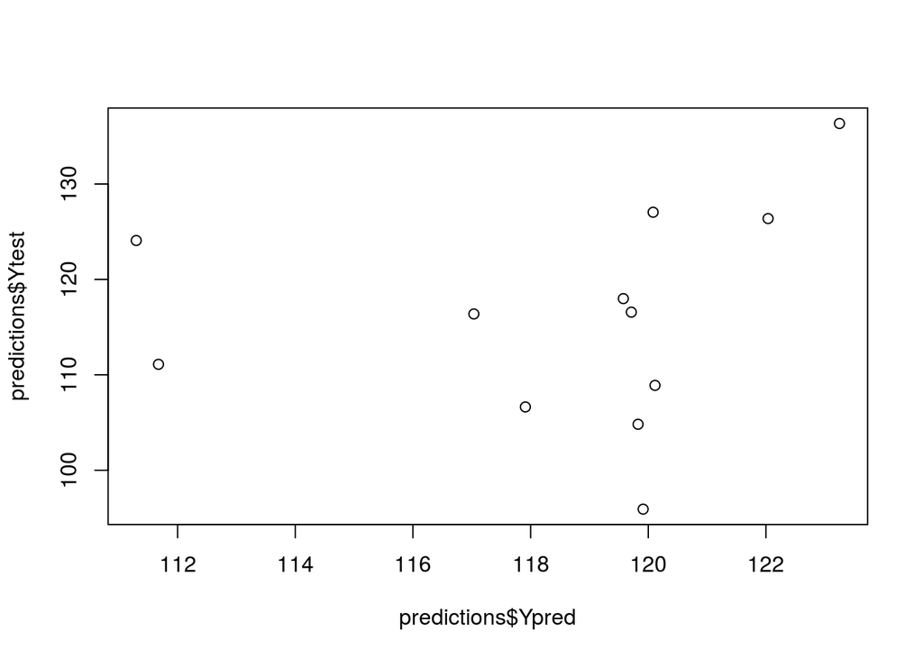

```r
plot(predictions$Ypred,predictions$Ytest)
```

- Fam reps: SCALED, NO CENTERING

```r
cor.mat <- cor(t(scale(log2(fam.asreml.counts + 1),center=F,scale = T)))
TRAIN.fams <- lgep.fams
TEST.fams <- ew.fams

predictions <- okriging(idtest = TEST.fams,idtrain = TRAIN.fams,corlist = list(cor.mat),H2vec = c(.99),pheno = pheno.57,phenoname = "Volume")

cor(predictions$Ypred,predictions$Ytest)
```

```
## [1] 0.1798524
```

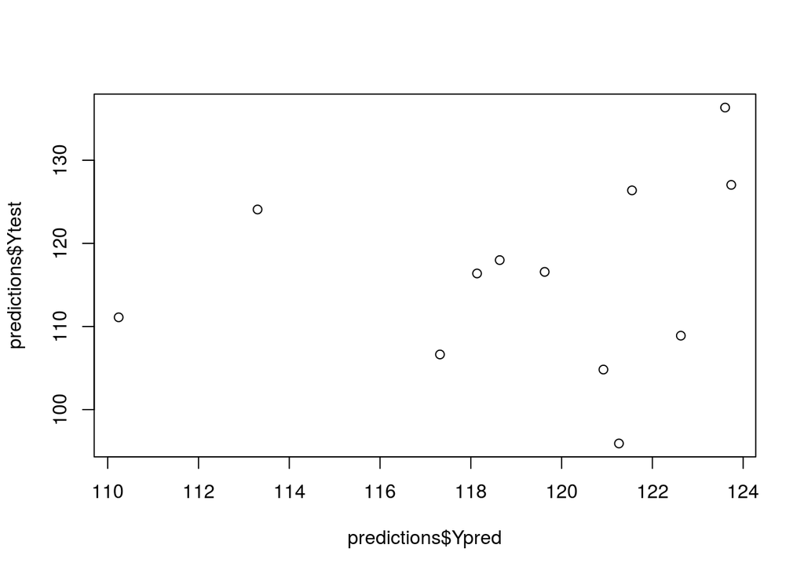

```r
plot(predictions$Ypred,predictions$Ytest)
```

- Fam reps: SCALED & CENTERED

```r
cor.mat <- cor(t(scale(log2(fam.asreml.counts + 1),center=T,scale = T)))
TRAIN.fams <- lgep.fams
TEST.fams <- ew.fams

predictions <- okriging(idtest = TEST.fams,idtrain = TRAIN.fams,corlist = list(cor.mat),H2vec = c(.99),pheno = pheno.57,phenoname = "Volume")

cor(predictions$Ypred,predictions$Ytest)
```

```
## [1] 0.1376874
```

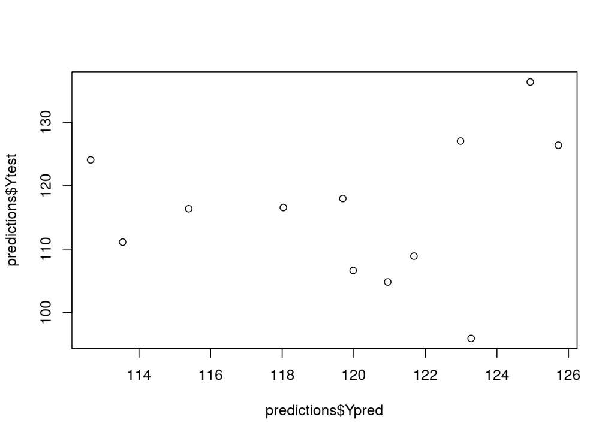

```r
plot(predictions$Ypred,predictions$Ytest)
```

*** The BEST results are either from SCALING/NO_CENTERING or NO SCALING/CENTERING.

### 0.5.2 BCV transcripts: FAMILY-level

- BCV > 1 NO SCALE/CENTER

```r
mean.cts <- apply(fam.asreml.counts,2,mean)
sd.cts <- apply(fam.asreml.counts,2,sd)
bcv.cts <- sd.cts/mean.cts
cor.mat <- cor(t(log2(fam.asreml.counts[,which(bcv.cts > 1)] + 1)))

TRAIN.fams <- lgep.fams
TEST.fams <- ew.fams

predictions <- okriging(idtest = TEST.fams,idtrain = TRAIN.fams,corlist = list(cor.mat),H2vec = c(.99),pheno = pheno.57,phenoname = "Volume")

cor(predictions$Ypred,predictions$Ytest)
```

```
## [1] 0.4817501
```

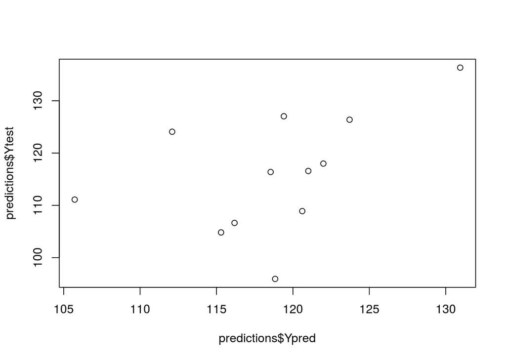

```r
plot(predictions$Ypred,predictions$Ytest)
```

- BCV > 1 SCALED, NO CENTERING

```r
cor.mat <- cor(t(scale(log2(fam.asreml.counts[,which(bcv.cts > 1)] + 1),center=F,scale = T)))

TRAIN.fams <- lgep.fams
TEST.fams <- ew.fams

predictions <- okriging(idtest = TEST.fams,idtrain = TRAIN.fams,corlist = list(cor.mat),H2vec = c(.99),pheno = pheno.57,phenoname = "Volume")

cor(predictions$Ypred,predictions$Ytest)
```

```
## [1] 0.4476559
```

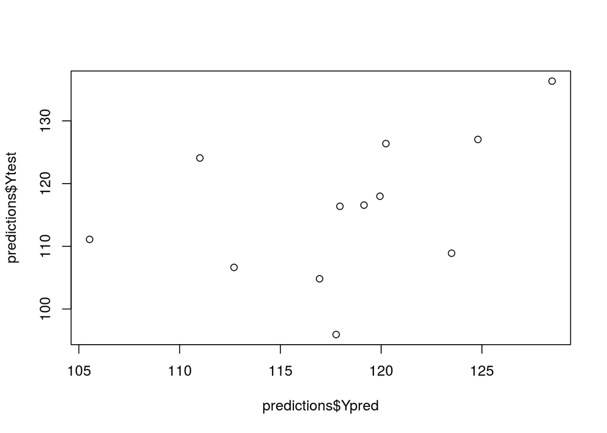

```r
plot(predictions$Ypred,predictions$Ytest)
```

- BCV > 1 SCALED & CENTERED

```r
cor.mat <- cor(t(scale(log2(fam.asreml.counts[,which(bcv.cts > 1)] + 1),center=T,scale = T)))

TRAIN.fams <- lgep.fams
TEST.fams <- ew.fams

predictions <- okriging(idtest = TEST.fams,idtrain = TRAIN.fams,corlist = list(cor.mat),H2vec = c(.99),pheno = pheno.57,phenoname = "Volume")

cor(predictions$Ypred,predictions$Ytest)
```

```
## [1] 0.4537157
```

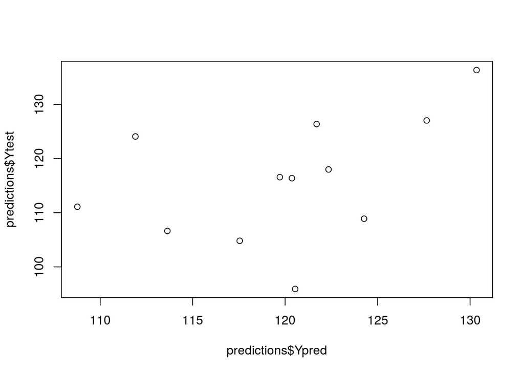

```r
plot(predictions$Ypred,predictions$Ytest)
```

*** The BEST result using BCV is done with NO CENTERING/SCALING

### 0.5.3 Linear model regression

- Conduct a linear regression from the LGEP against Volume and use sig txpts to predict EW

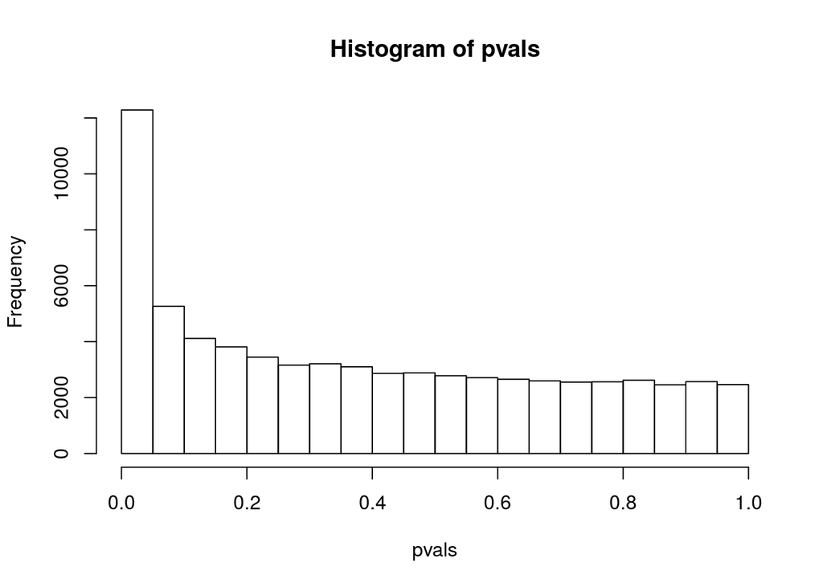

```r
# identify rows which correspond to LGEP

train.counts <- asreml.counts[which(fam.phenos$fam_id %in% lgep.fams),]
train.phenos <- fam.phenos[which(fam.phenos$fam_id %in% lgep.fams),]

pvals <- mclapply(1:ncol(train.counts),function(each.txpt){
  txpt <- train.counts[,each.txpt]
  summary(lm(train.phenos$Volume ~ txpt))[[4]][[8]]
})
pvals <- unlist(pvals)
hist(pvals)
```

##### 0.5.3.0.1 Use straight p-vals

- Try subsetting on p-value with NO fdr adjustment: 0.05, 0.01, 0.001, 0.0001

```r
p.val.subset <- .05
cor.mat <- cor(t(scale(log2(fam.asreml.counts[,which(pvals <= p.val.subset)] + 1),center=F,scale = T)))

TRAIN.fams <- lgep.fams
TEST.fams <- ew.fams

predictions <- okriging(idtest = TEST.fams,idtrain = TRAIN.fams,corlist = list(cor.mat),H2vec = c(.99),pheno = pheno.57,phenoname = "Volume")
#predictions[,2:3] <- predictions[,2:3] - mean(pheno.57$Volume[which(pheno.57$fam_id %in% lgep.fams)])
cor(predictions$Ypred,predictions$Ytest)
```

```
## [1] 0.2599208
```

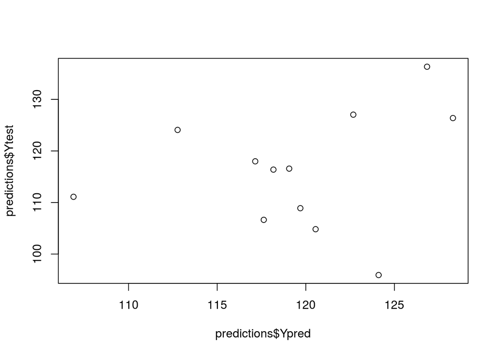

```r
plot(predictions$Ypred,predictions$Ytest)
```

```r
# Subset test families from pheno data to see volume accuracy
test.phenos <- pheno.57[which(as.character(predictions$IID) %in% pheno.57$fam_id),]
low.acc.fams <- test.phenos$fam_id[which(test.phenos$`Volume Accuracy` < .9)]
high.acc.pred <- predictions[-which(as.character(predictions$IID) %in% low.acc.fams ),]

cor(high.acc.pred$Ypred,high.acc.pred$Ytest)
```

```
## [1] 0.3774007
```

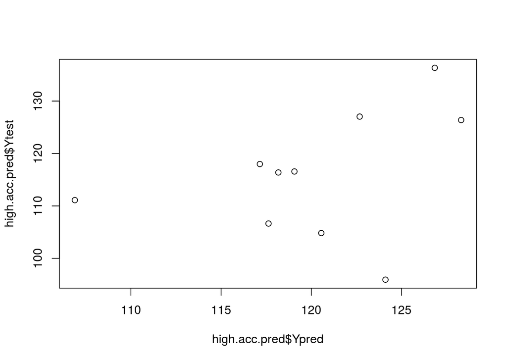

```r
plot(high.acc.pred$Ypred,high.acc.pred$Ytest)
```

```r
p.val.subset <- .01
cor.mat <- cor(t(scale(log2(fam.asreml.counts[,which(pvals <= p.val.subset)] + 1),center=F,scale = T)))

TRAIN.fams <- lgep.fams
TEST.fams <- ew.fams

predictions <- okriging(idtest = TEST.fams,idtrain = TRAIN.fams,corlist = list(cor.mat),H2vec = c(.99),pheno = pheno.57,phenoname = "Volume")
#predictions[,2:3] <- predictions[,2:3] - mean(pheno.57$Volume[which(pheno.57$fam_id %in% lgep.fams)])
cor(predictions$Ypred,predictions$Ytest)
```

```
## [1] 0.3778898
```

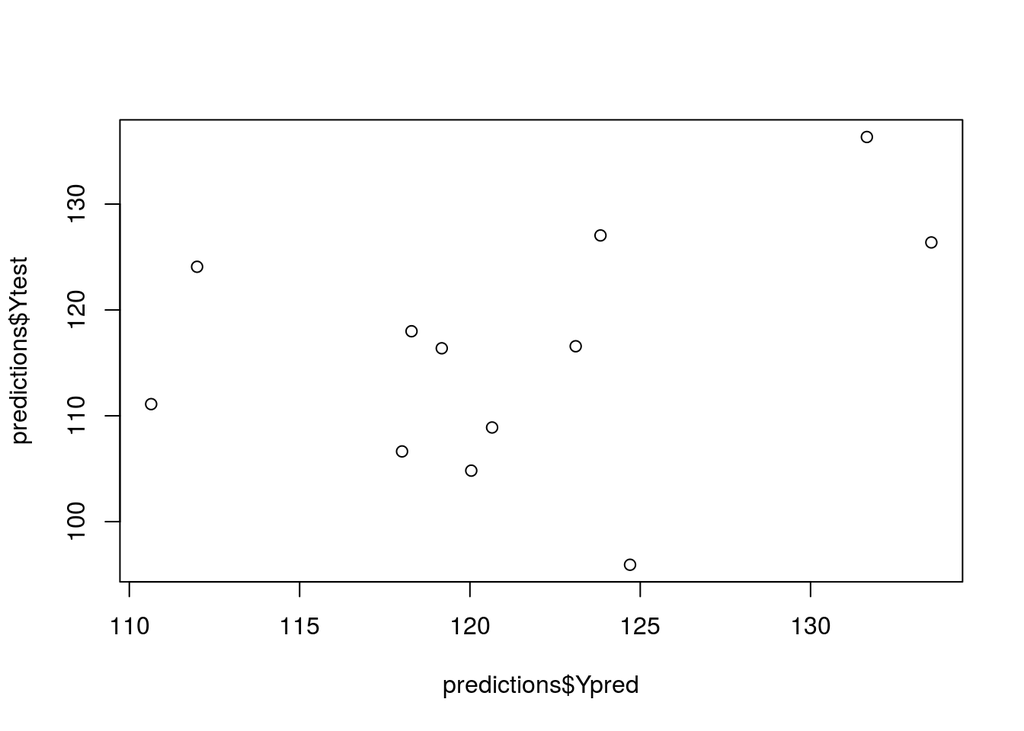

```r
plot(predictions$Ypred,predictions$Ytest)
```

```r
# Subset test families from pheno data to see volume accuracy
test.phenos <- pheno.57[which(as.character(predictions$IID) %in% pheno.57$fam_id),]
low.acc.fams <- test.phenos$fam_id[which(test.phenos$`Volume Accuracy` < .9)]
high.acc.pred <- predictions[-which(as.character(predictions$IID) %in% low.acc.fams ),]

cor(high.acc.pred$Ypred,high.acc.pred$Ytest)
```

```
## [1] 0.5374803
```

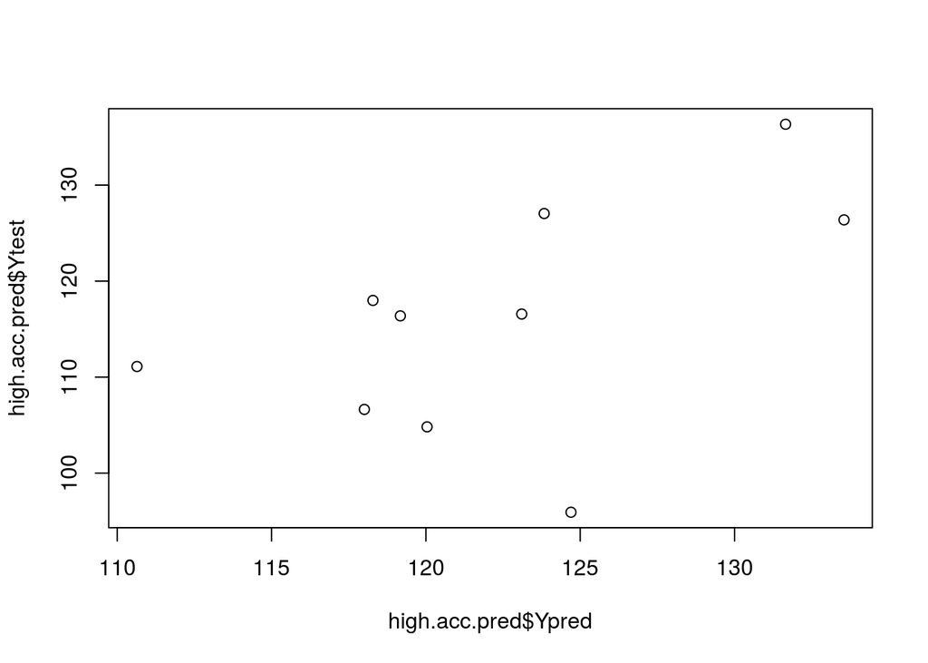

```r
plot(high.acc.pred$Ypred,high.acc.pred$Ytest)
```

```r
p.val.subset <- .001
cor.mat <- cor(t(scale(log2(fam.asreml.counts[,which(pvals <= p.val.subset)] + 1),center=F,scale = T)))

TRAIN.fams <- lgep.fams
TEST.fams <- ew.fams

predictions <- okriging(idtest = TEST.fams,idtrain = TRAIN.fams,corlist = list(cor.mat),H2vec = c(.99),pheno = pheno.57,phenoname = "Volume")
#predictions[,2:3] <- predictions[,2:3] - mean(pheno.57$Volume[which(pheno.57$fam_id %in% lgep.fams)])
cor(predictions$Ypred,predictions$Ytest)
```

```
## [1] 0.553967
```

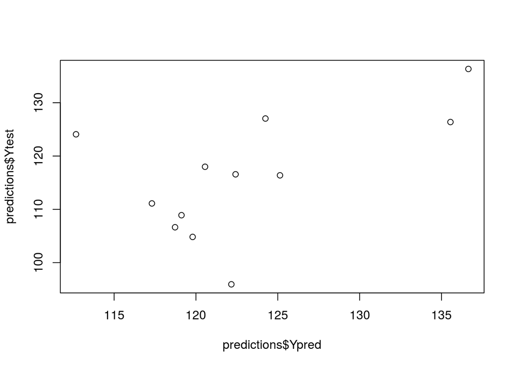

```r
plot(predictions$Ypred,predictions$Ytest)
```

```r
# Subset test families from pheno data to see volume accuracy
test.phenos <- pheno.57[which(as.character(predictions$IID) %in% pheno.57$fam_id),]
low.acc.fams <- test.phenos$fam_id[which(test.phenos$`Volume Accuracy` < .9)]
high.acc.pred <- predictions[-which(as.character(predictions$IID) %in% low.acc.fams ),]

cor(high.acc.pred$Ypred,high.acc.pred$Ytest)
```

```
## [1] 0.748861
```

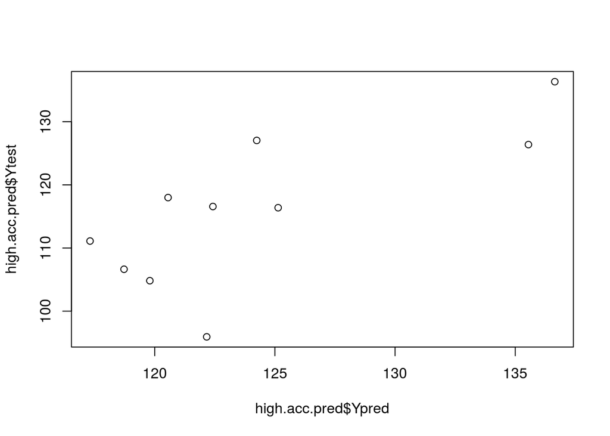

```r
plot(high.acc.pred$Ypred,high.acc.pred$Ytest)
```

```r
p.val.subset <- .0001
cor.mat <- cor(t(scale(log2(fam.asreml.counts[,which(pvals <= p.val.subset)] + 1),center=F,scale = T)))

TRAIN.fams <- lgep.fams
TEST.fams <- ew.fams

predictions <- okriging(idtest = TEST.fams,idtrain = TRAIN.fams,corlist = list(cor.mat),H2vec = c(.99),pheno = pheno.57,phenoname = "Volume")
#predictions[,2:3] <- predictions[,2:3] - mean(pheno.57$Volume[which(pheno.57$fam_id %in% lgep.fams)])
cor(predictions$Ypred,predictions$Ytest)
```

```
## [1] 0.5362572
```

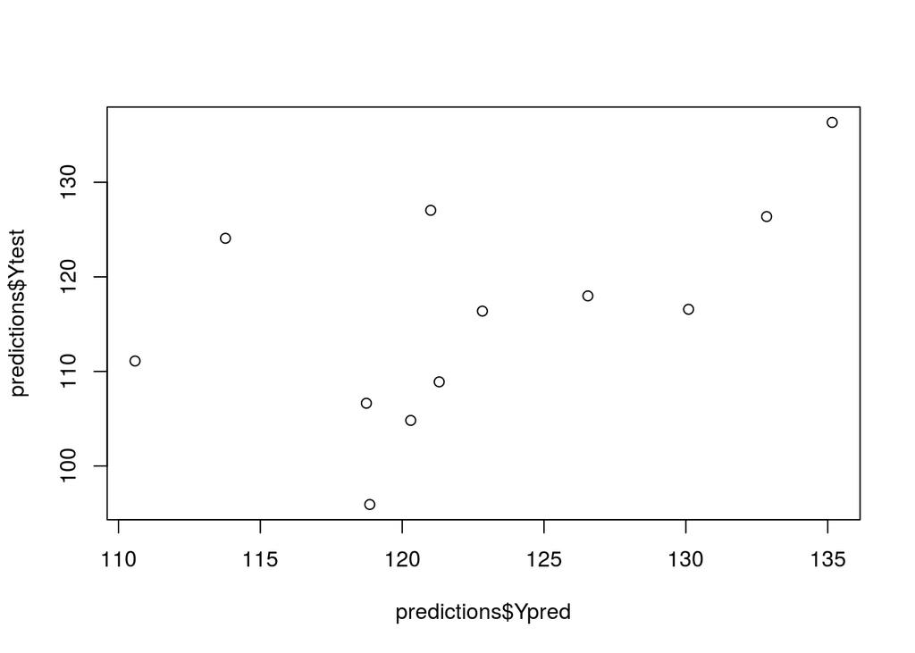

```r
plot(predictions$Ypred,predictions$Ytest)
```

```r
# Subset test families from pheno data to see volume accuracy
test.phenos <- pheno.57[which(as.character(predictions$IID) %in% pheno.57$fam_id),]
low.acc.fams <- test.phenos$fam_id[which(test.phenos$`Volume Accuracy` < .9)]
high.acc.pred <- predictions[-which(as.character(predictions$IID) %in% low.acc.fams ),]

cor(high.acc.pred$Ypred,high.acc.pred$Ytest)
```

```
## [1] 0.686953
```

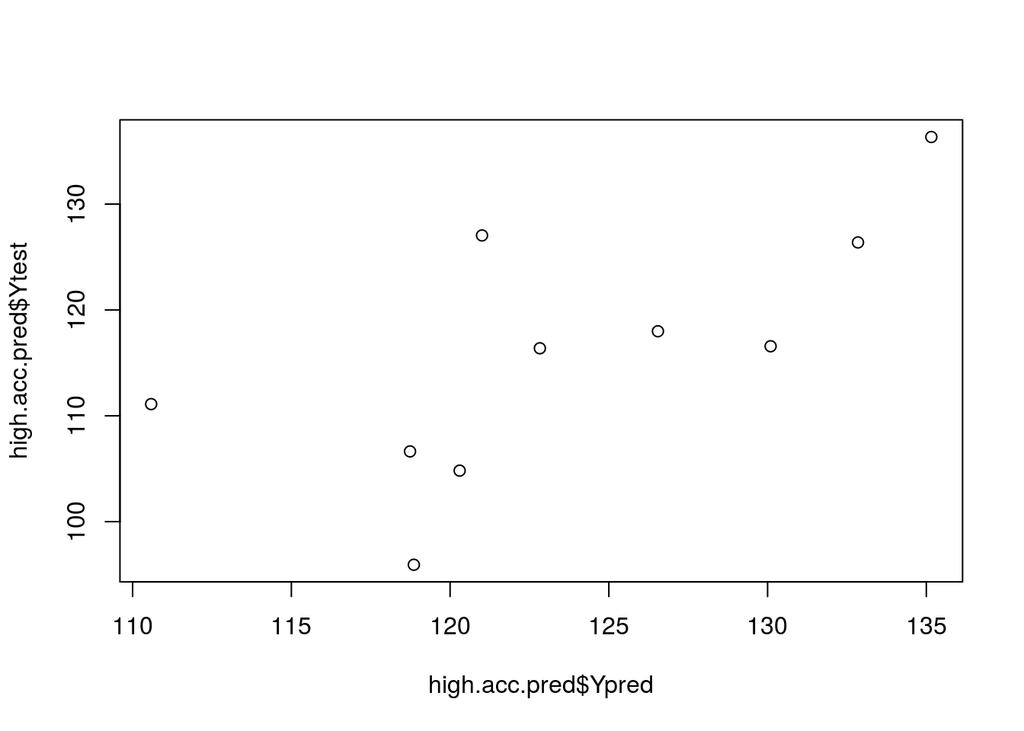

```r
plot(high.acc.pred$Ypred,high.acc.pred$Ytest)
```

##### 0.5.3.0.2 Use pval adjust

- Generate the adjusted p-values

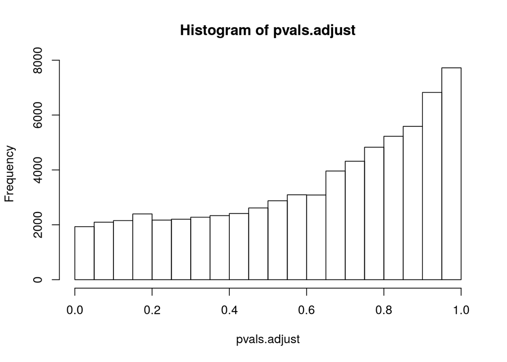

```r
pvals.adjust <- p.adjust(p = pvals,method = "fdr")
hist(pvals.adjust)
```

- Try subsetting on p-value with fdr adjustment: 0.05, .025, 0.01, 0.005

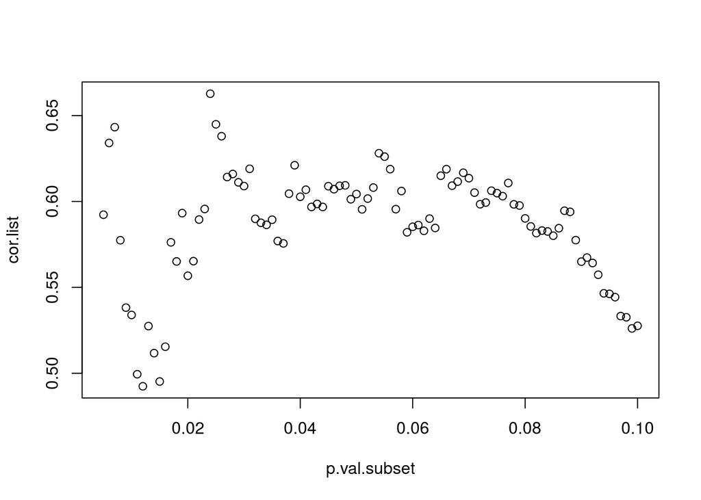

```r
# Subset test families from pheno data to see volume accuracy
test.phenos <- pheno.57[which(as.character(predictions$IID) %in% pheno.57$fam_id),]
low.acc.fams <- test.phenos$fam_id[which(test.phenos$`Volume Accuracy` < .9)]

p.val.subset <- seq(to = .1,from = .005,by = .001); cor.weight = .75
cor.list <- c(); high.acc.cor.list <- c()
rmse.list <- c(); high.acc.rmse.list <- c()

for(each in 1:length(p.val.subset)){
cor.mat <- cor(t(scale(log2(fam.asreml.counts[,which(pvals.adjust <= p.val.subset[each])] + 1),center=F,scale = T)))

TRAIN.fams <- lgep.fams
TEST.fams <- ew.fams

predictions <- okriging(idtest = TEST.fams,idtrain = TRAIN.fams,corlist = list(cor.mat),H2vec = c(cor.weight),pheno = pheno.57,phenoname = "Volume")
predictions[,2:3] <- predictions[,2:3] - mean(pheno.57$Volume[which(pheno.57$fam_id %in% lgep.fams)])
high.acc.pred <- predictions[-which(as.character(predictions$IID) %in% low.acc.fams ),]

cor.list <- c(cor.list,cor(predictions$Ypred,predictions$Ytest))
high.acc.cor.list <- c(high.acc.cor.list,cor(high.acc.pred$Ypred,high.acc.pred$Ytest))

rmse.list <- c(rmse.list,rmse(predicted = predictions$Ypred,actual = predictions$Ytest))
high.acc.rmse.list <- c(high.acc.rmse.list,rmse(predicted = high.acc.pred$Ypred,actual = high.acc.pred$Ytest))
}

# Plot correlation as a function of p-value subset
plot(p.val.subset,cor.list)
```

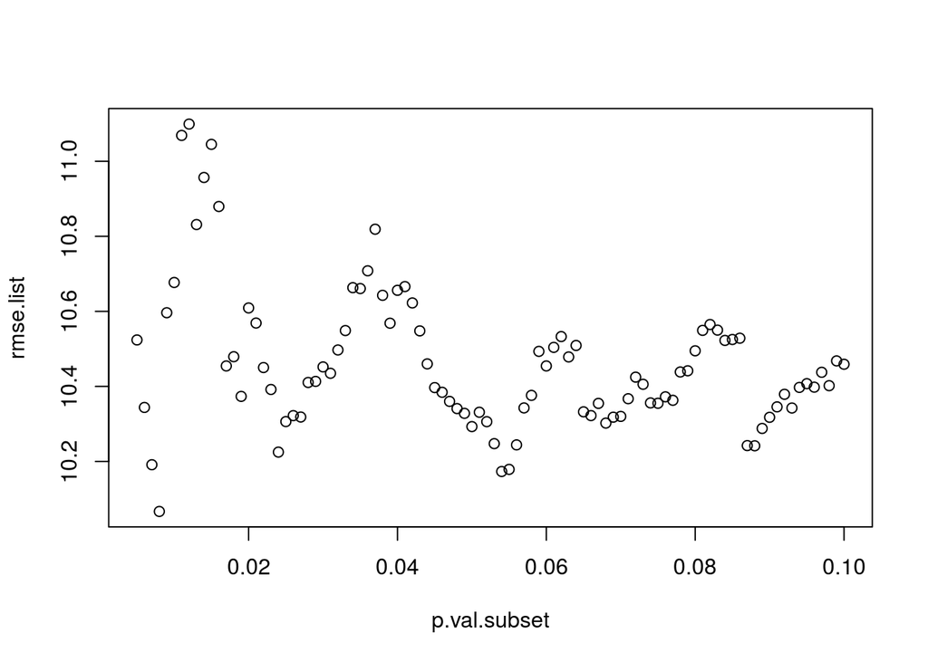

```r
plot(p.val.subset,rmse.list)
```

```r
summary(cor.list)
```

```
##    Min. 1st Qu.  Median    Mean 3rd Qu.    Max.
##  0.4924  0.5768  0.5943  0.5870  0.6083  0.6627
```

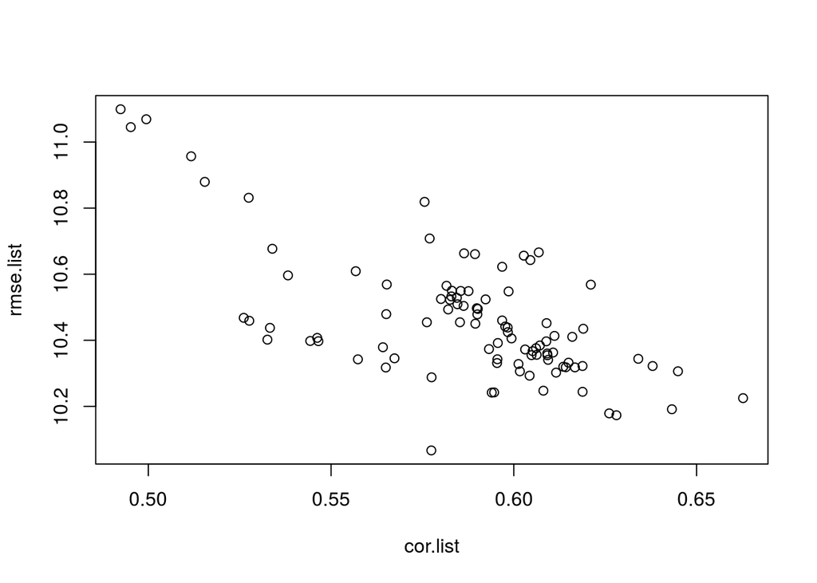

```r
plot(cor.list,rmse.list)
```

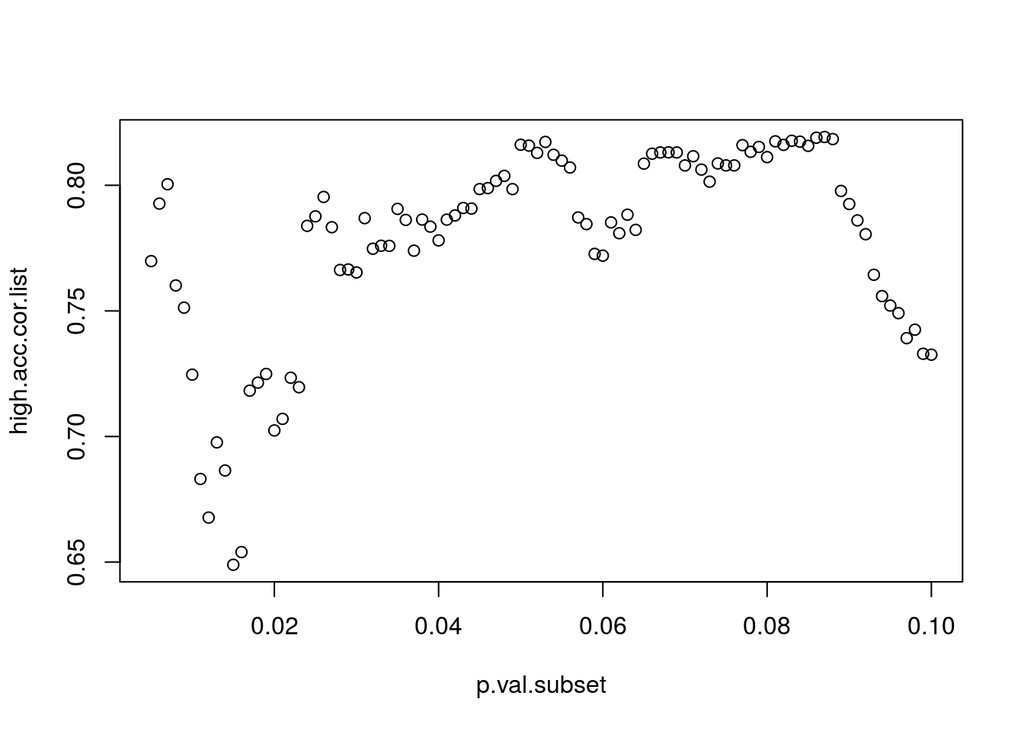

```r
# Plot correlation of high accuracy BV's as a function of p-value subset
plot(p.val.subset,high.acc.cor.list)
```

```r
summary(high.acc.cor.list)
```

```
##    Min. 1st Qu.  Median    Mean 3rd Qu.    Max.
##  0.6490  0.7651  0.7871  0.7776  0.8087  0.8192
```

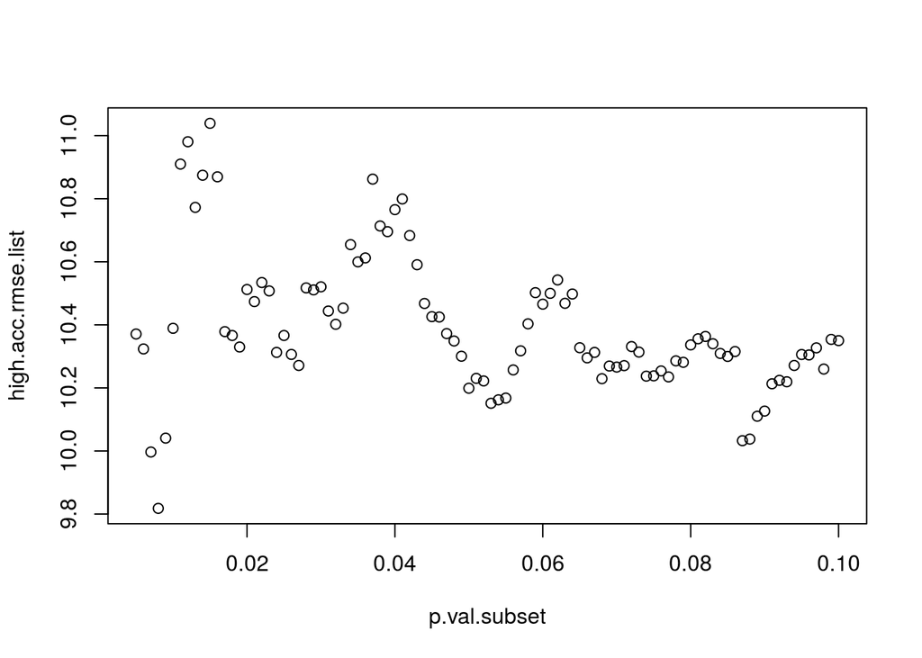

```r
plot(p.val.subset,high.acc.rmse.list)
```

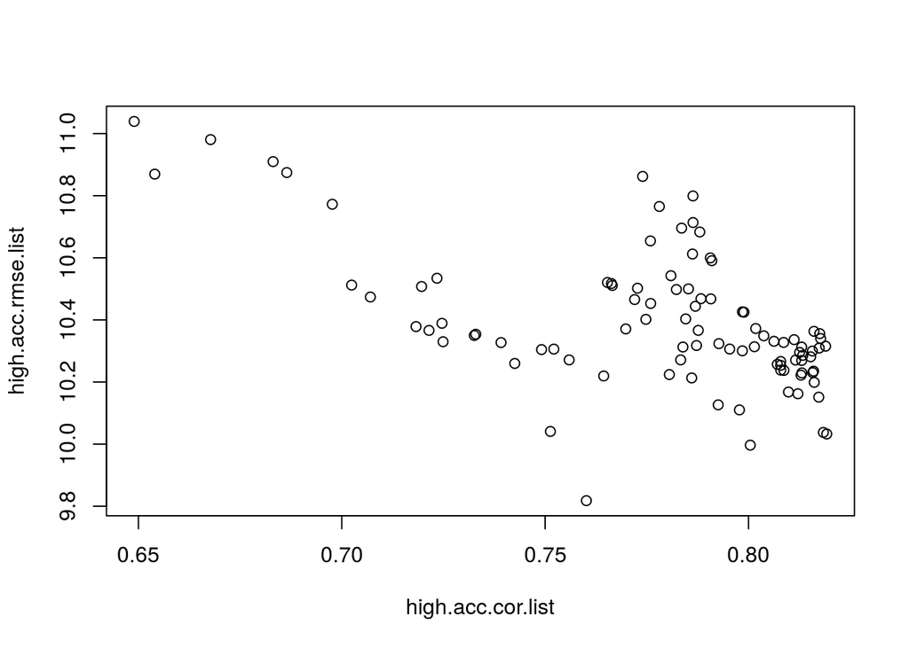

```r
plot(high.acc.cor.list,high.acc.rmse.list)
```

```r
p.val.subset <- .025
cor.mat <- cor(t(scale(log2(fam.asreml.counts[,which(pvals.adjust <= p.val.subset)] + 1),center=F,scale = T)))

TRAIN.fams <- lgep.fams
TEST.fams <- ew.fams

predictions <- okriging(idtest = TEST.fams,idtrain = TRAIN.fams,corlist = list(cor.mat),H2vec = c(.99),pheno = pheno.57,phenoname = "Volume")
#predictions[,2:3] <- predictions[,2:3] - mean(pheno.57$Volume[which(pheno.57$fam_id %in% lgep.fams)])
cor(predictions$Ypred,predictions$Ytest)
```

```
## [1] 0.6222695
```

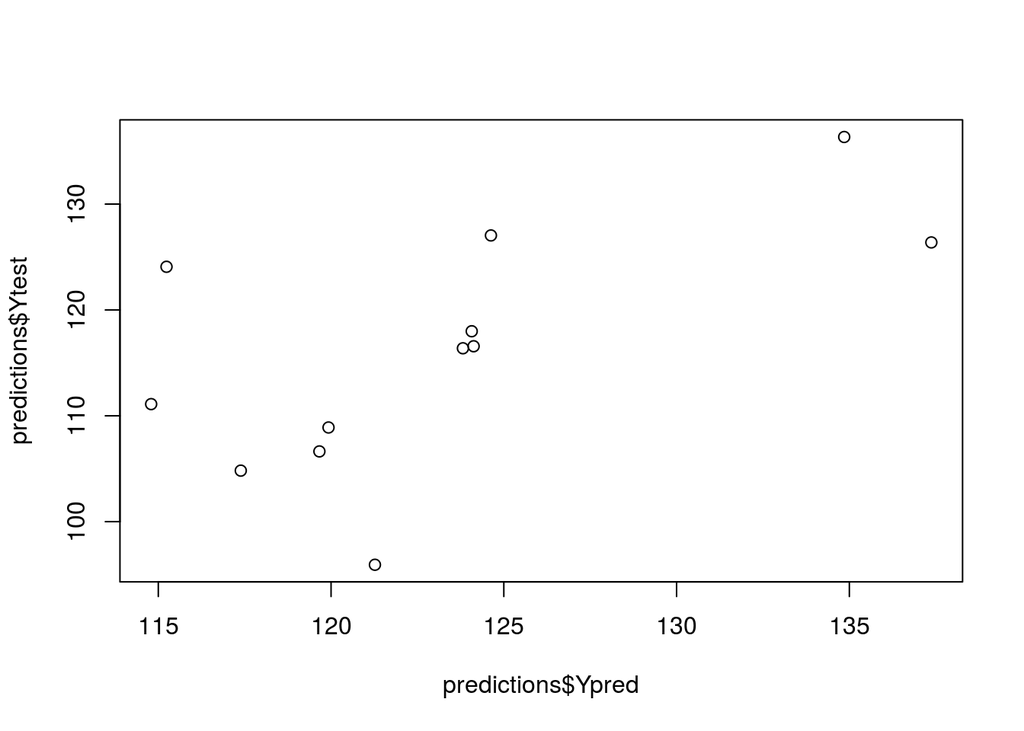

```r
plot(predictions$Ypred,predictions$Ytest)
```

```r
# Subset test families from pheno data to see volume accuracy
test.phenos <- pheno.57[which(as.character(predictions$IID) %in% pheno.57$fam_id),]
low.acc.fams <- test.phenos$fam_id[which(test.phenos$`Volume Accuracy` < .9)]
high.acc.pred <- predictions[-which(as.character(predictions$IID) %in% low.acc.fams ),]
cor(high.acc.pred$Ypred,high.acc.pred$Ytest)^2
```

```
## [1] 0.5812752
```

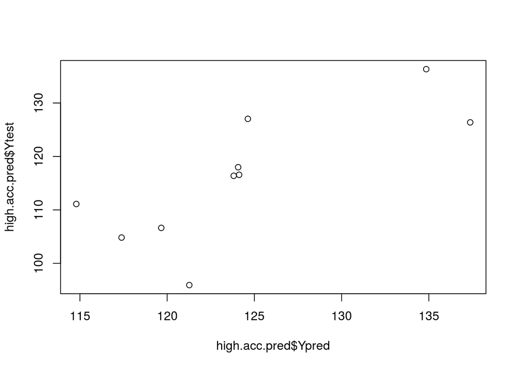

```r
plot(high.acc.pred$Ypred,high.acc.pred$Ytest)
```

```r
p.val.subset <- .001
cor.mat <- cor(t(scale(log2(fam.asreml.counts[,which(pvals.adjust <= p.val.subset)] + 1),center=F,scale = T)))

TRAIN.fams <- lgep.fams
TEST.fams <- ew.fams

predictions <- okriging(idtest = TEST.fams,idtrain = TRAIN.fams,corlist = list(cor.mat),H2vec = c(.99),pheno = pheno.57,phenoname = "Volume")
#predictions[,2:3] <- predictions[,2:3] - mean(pheno.57$Volume[which(pheno.57$fam_id %in% lgep.fams)])
cor(predictions$Ypred,predictions$Ytest)
```

```
## [1] 0.1472163
```

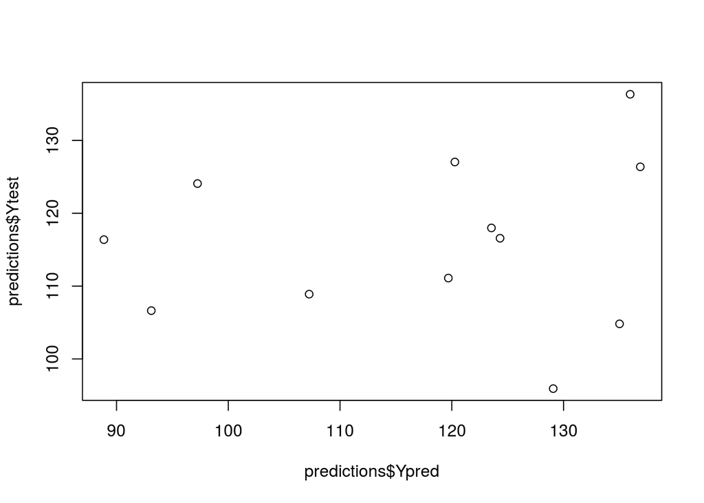

```r
plot(predictions$Ypred,predictions$Ytest)
```

```r
# Subset test families from pheno data to see volume accuracy
test.phenos <- pheno.57[which(as.character(predictions$IID) %in% pheno.57$fam_id),]
low.acc.fams <- test.phenos$fam_id[which(test.phenos$`Volume Accuracy` < .9)]
high.acc.pred <- predictions[-which(as.character(predictions$IID) %in% low.acc.fams ),]

cor(high.acc.pred$Ypred,high.acc.pred$Ytest)
```

```
## [1] 0.2225185
```

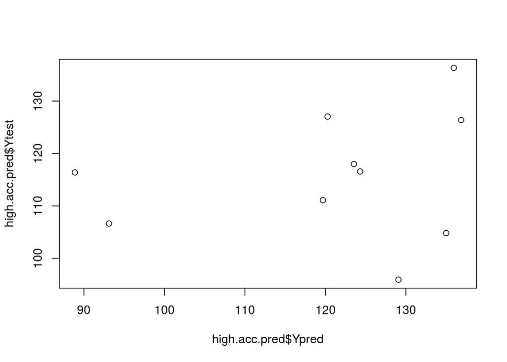

```r
plot(high.acc.pred$Ypred,high.acc.pred$Ytest)
```

#### 0.5.3.1 HYBRID APPROACH

- Try a hybrid approach which leverages biological replicates of training set to predict a family level input

```r
# train.counts contains LGEP counts & train.phenos contain the phenos
# Join the family level information for prediction
test.phenos <- pheno.57[which(pheno.57$fam_id %in% ew.fams),]
low.acc.fams <- which(test.phenos$`Volume Accuracy` < .9)

hybrid.phenos <- rbind(train.phenos[,c("fam_id","Volume","Volume Accuracy")],test.phenos)
rownames(hybrid.phenos)
```

[output not shown]

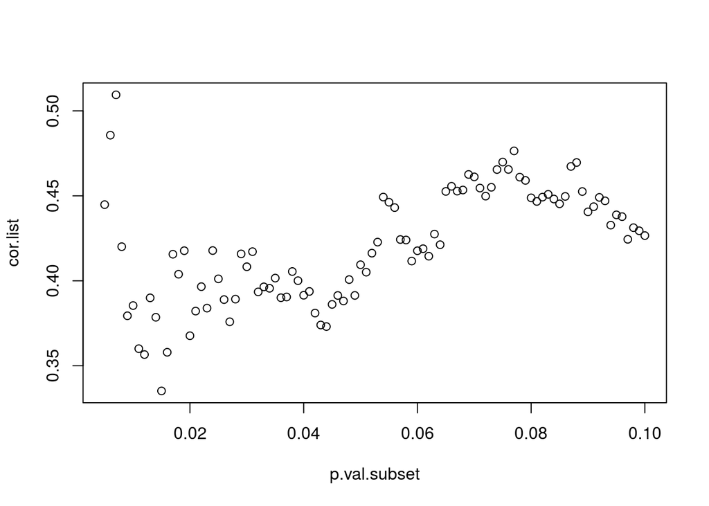

```r
hybrid.counts <- rbind(train.counts,fam.asreml.counts[which( pheno.57$fam_id %in% ew.fams),])

p.val.subset <- seq(to = .1,from = .005,by = .001); cor.weight = .75
cor.list <- c(); high.acc.cor.list <- c()
rmse.list <- c(); high.acc.rmse.list <- c()

for(each in 1:length(p.val.subset)){
cor.mat <- cor(t(scale(log2(hybrid.counts[,which(pvals.adjust <= p.val.subset[each])] + 1),center=F,scale = T)))
colnames(cor.mat) <- c(1:ncol(cor.mat)); rownames(cor.mat) <- c(1:ncol(cor.mat))
rownames(hybrid.phenos) <- 1:ncol(cor.mat)

TEST.fams <- which(hybrid.phenos$fam_id %in% ew.fams)
TRAIN.fams <- c(1:ncol(cor.mat))[-TEST.fams]

predictions <- okriging(idtest = TEST.fams,idtrain = TRAIN.fams,corlist = list(cor.mat),H2vec = c(cor.weight),pheno = hybrid.phenos,phenoname = "Volume")
predictions[,2:3] <- predictions[,2:3] - mean(pheno.57$Volume[which(pheno.57$fam_id %in% lgep.fams)])
high.acc.pred <- predictions[-low.acc.fams,]

cor.list <- c(cor.list,cor(predictions$Ypred,predictions$Ytest))
high.acc.cor.list <- c(high.acc.cor.list,cor(high.acc.pred$Ypred,high.acc.pred$Ytest))

rmse.list <- c(rmse.list,rmse(predicted = predictions$Ypred,actual = predictions$Ytest))
high.acc.rmse.list <- c(high.acc.rmse.list,rmse(predicted = high.acc.pred$Ypred,actual = high.acc.pred$Ytest))
}

# Plot correlation as a function of p-value subset
plot(p.val.subset,cor.list)
```

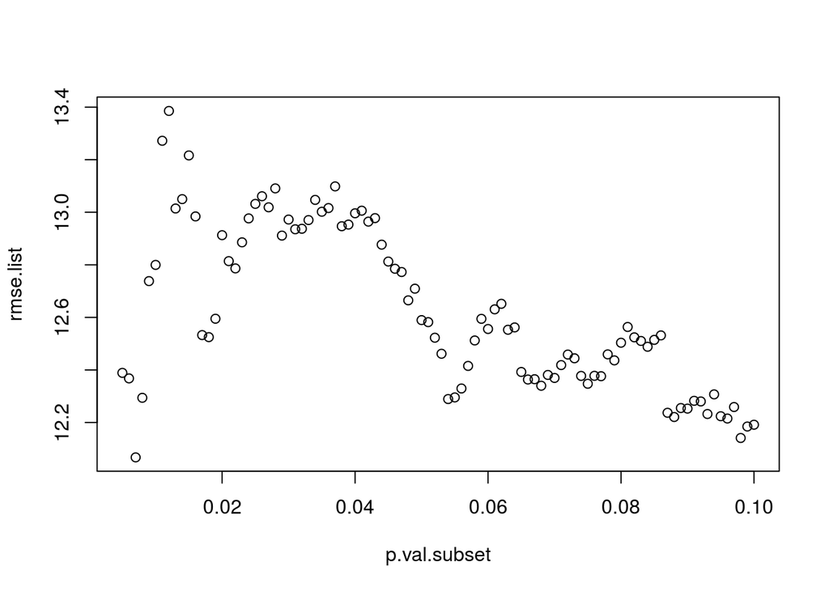

```r
plot(p.val.subset,rmse.list)
```

```r
summary(cor.list)
```

```
##    Min. 1st Qu.  Median    Mean 3rd Qu.    Max.
##  0.3352  0.3930  0.4195  0.4209  0.4491  0.5095
```